# CMM535 Coursework PART 1

SAMUEL ONEKUTU 2114194, School of Computing, Robert Gordon University Aberdeen

3/11/2022

#### Data Preparation, Exploration with Machine Learning in R

#### using two data set ‘escapes.csv’:records of fish escapes and ‘analysis.csv’: the water analysis

~~~~~~~~~~~~~~~~~~~~~~~~~~~~~~~~~~~~~~~~~~~~~~~~~~~~~~~~~~~~~~~~~~~~~~~~~~~~~~~~~~~

##### Importing CSV Files

Importing the two data sets from my local directory.

```r
#getwd()                                              # show current directory
escapes_ori <- read.csv("escapes.csv",header = T,stringsAsFactors = T)
analysis_ori <- read.csv("analysis.csv",header = T,stringsAsFactors = T)  # original data import, setting string values as factors for evaluation
```

##### Importing the neccessary libraries

*rlang* for base type core R features. *caret* for preprocessing, classification and Regression training *ggplot2* for visualizations, *dplyr* data manipulation, *Hmisc* other functions , *stringr* for strings and characters operations, *corrplot* for correlation grid plot , *randomForest* for random forest classifier.

```r
library (rlang)
library (caret)
library (ggplot2)
library (dplyr)
library (Hmisc)
library (stringr)
library(corrplot)
library(randomForest)
```

### 1. Data Preparations

I would begin by reviewing and cleaning the columns/features of interest and identifying other related and relevant features based on the problem question. then I would remove duplicate/irrelevant columns and then deal with Missing values. my work on the individual features will involving looking out for: * typo and difference in spellings * difference in units of measurement * incorrect data type and out of range value * missing data and * transformations starting with the three focus feature and base on domain knowledge generally. “Escaped.Species” is cleanest, attention would be directed to the “Age” and “Average.weight” features, also with *“Escaped.Number”* and the *“Dates”* would be transformed to help with the merging task

#### 1.1 Preparing my Datasets ‘escapes_ori’

Firstly, the column dimensions,column names and summary of the dataset.(kindly refer to appendix for full print of the summary)

```r
dim(escapes_ori)
```

```
## [1] 357  38
```

From result above we have 357 instances and 38 columns. i would begin by exploring the data’s summary

```r
names(escapes_ori)
```

```
##  [1] "Escape.ID"                  "Operator.at.Time.of.Escape"
##  [3] "Escape.Water.Type"          "Escape.Start.Date"
##  [5] "Escape.Start.Time"          "Escape.End.Time"
##  [7] "Escape.Grid.Reference"      "Escaped.Species"
##  [9] "Stage"                      "Age"
## [11] "Average.Weight"             "Initial.Date.of.Escape"
## [13] "Initial.Number.Escaped"     "Initial.Escape.Reason"
## [15] "Final.Date.of.Escape"       "Final.Number.Escaped"
## [17] "Final.Number.Recovered"     "Final.Escape.Reason"
## [19] "Marine.Scotland.Site.ID"    "Date.Registered"
## [21] "Site.Name"                  "National.Grid.Reference"
## [23] "Local.Authority"            "Producing.in.Last.3.Years"
## [25] "Site.Address.1"             "Site.Address.2"
## [27] "Site.Address.3"             "Site.Post.Code"
## [29] "Site.Contact.Number"        "Aquaculture.Type"
## [31] "Water.Type"                 "Health.Surveillance"
## [33] "Easting"                    "Northing"
## [35] "MS.Management.Area"         "Region"
## [37] "Operator"                   "Species"
```

```r
#summary(escapes_ori) # kindly refer to appendix for full print of the summary
```

creating a copy of original escapes as “escapes”

```r
escapes<- escapes_ori
```

##### 1.1.1 Cleaning “Average.Weight” Feature

The Aim is to have Weight as *Kilograms* and in numeric form. convert Average.weight to string so I can make use of *stringr* library to clean.

but first defining non_alpha-numeric and others variables for cleaning.

```r
non_alpha_num <- " '[!\"#$%&\\()*+-,/:;<=>?@\\^_`{|}~\a\b\t\n\r\v\f] "# i removed"."so it does not affect floats
non_alpha_num_ <- " '[!\"#$%&\\()*+-,/:;<=>?@.\\^_`{|}~\a\b\t\n\r\v\f] "
non_num <- paste(c('[',letters, LETTERS, non_alpha_num,']'), collapse="") # defining all string and characters
non_num_<- paste(c('[',letters, LETTERS, non_alpha_num_,']'), collapse="") #extended non_num adding "." back
com_letters<-  paste(c('[',letters, LETTERS," ",']'), collapse="")  # only upper and lower case
```

reviewing the Average.weight feature for cleaning.

```r
escapes$Average.Weight <- as.character(escapes$Average.Weight)
class(escapes$Average.Weight)
```

```
## [1] "character"
```

```r
#print(escapes$Average.Weight)
```

1. Dealing with range values e.g 1-2kg or 2-5 grams. the code below will detect for “kg” and treat and also for the rest assuming they will be in grams (g).

```r
findmean_kg<- function(strg){
  if (grepl("-",strg) & grepl("kg",strg)){
    strg = str_remove_all(strg,com_letters )            # find mean between weight(kg) in ranges(-)
    minus = str_locate(strg,"-")[1,1];
    num1 = as.numeric(substr(strg,0,minus-1));
    num2 = as.numeric(substr(strg,minus+1,nchar(strg)));
    return(as.character(mean(c(num1,num2))))
  }
  else if (grepl("-",strg)){
    strg = str_remove_all(strg,com_letters )            # assuming all other unit not kg are grams or g
    minus = str_locate(strg,"-")[1,1];
    num1 = as.numeric(substr(strg,0,minus-1));
    num2 = as.numeric(substr(strg,minus+1,nchar(strg)));
    return(as.character(mean(c(num1,num2))/1000))
  }
  else
    {return(strg)}                                 # return contain unchanged for futher cleaning
}
# applying function.
escapes$Average.Weight <- sapply(escapes$Average.Weight,findmean_kg)
```

2. I found two instances that Age and Average.weight were swapped, for lack of the right code to correct this, I would manually locate the instances *76 and 337* and make switch. also at instance *49* and *75*.

```r
escapes$Age <- as.character(escapes$Age)  # to allow the make swap with elements of same class character

age_76 <- escapes$Average.Weight[76]
weight_76 <- escapes$Age[76]
escapes$Average.Weight[76]<- weight_76
escapes$Age[76]<-age_76

age_337 <- escapes$Average.Weight[337]
weight_337 <- escapes$Age[337]
escapes$Average.Weight[337]<- weight_337
escapes$Age[337]<-age_337
# lastly this was detected
escapes$Average.Weight[49]<- mean(0.75,2) # originally captured as("750g-2kg")
escapes$Age[49]<- ("2000") # originally captured as("2000 & 200")
escapes$Age[75]<- ("2000") # originally captured as("2000 & 200")
escapes$Escape.ID<-as.factor(escapes$Escape.ID)
```

3. dealing with the units converting grams to “kg” and return everything as numeric

```r
to_kilo <- function(strg){
  if (grepl("k",strg)){return(as.numeric(str_remove_all(strg,non_num)))} #detect k or kg or kilo
  else if (grepl("g",strg)){
    strg = str_remove_all(strg,non_num)
    strg = (as.numeric(strg))/1000                        #detect g or grams and convert
    return(strg)}
  else {return(as.numeric(str_remove_all(strg,non_num)))}  # convert other and unknowns to NA's
}

#applying the function
escapes$Average.Weight<- sapply(escapes$Average.Weight, to_kilo)
```

allowed one erroneous entire was coerced to NA.

```r
summary(escapes$Average.Weight)
```

```
##     Min.  1st Qu.   Median     Mean  3rd Qu.     Max.     NA's
##  0.01079  0.39750  1.85000  2.07821  3.20000 10.00000       21
```

```r
#escapes$Average.Weight
```

##### 1.1.2 cleaning “Age” Feature

Aim is to have age as *months* and in numeric form.

```r
#print(escapes$Age)
```

From review of Age column I found issues for example: 22 unknowns,entries like ‘2001_s1’, 16 NA’s, others like; 14mths, symbols, weeks e.t.c so starting with;

1. converting Age to string so I can apply string functions to it

```r
escapes$Age <- as.character(escapes$Age)
class(escapes$Age)
```

```
## [1] "character"
```

2. converting the NA’s to characters to enable me run string cleaning methods on entire column later.

```r
escapes$Age<- as.character(escapes$Age)
escapes$Age[is.na(escapes$Age)]<-"unknown"
```

3. defining string functions to get the average of values between “-” and “&”, findmean1 and findmean2 respectively

```r
findmean1<- function(strg){
  if (grepl("-",strg)){
    strg = str_remove_all(strg,com_letters )            # remove all other string apart from numbers
    minus = str_locate(strg,"-")[1,1];
    num1 = as.numeric(substr(strg,0,minus-1));
    num2 = as.numeric(substr(strg,minus+1,nchar(strg)));
    return(as.character(mean(c(num1,num2))))
  }
  else {return(strg)}
}

escapes$Age <- sapply(escapes$Age,findmean1)
```

```r
findmean2<- function(strg){
  if (grepl("&",strg)){
    strg = str_remove_all(strg,com_letters)
    and = str_locate(strg,"&")[1,1];
    num1 = as.numeric(substr(strg,0,and-1));
    num2 = as.numeric(substr(strg,and+1,nchar(strg))); # from start of 2no. to end of string
    return(as.character(mean(c(num1,num2))))
  }
  else {return(strg)}
}

escapes$Age <- sapply(escapes$Age,findmean2)
```

4. locating age captured as yrs and converting to numeric months

```r
# find yrs and convert to by multiplying by 12
conv_yrs<- function(age){
  if(grepl('yrs',age)){yrs=str_remove_all(age,non_num);months= as.numeric(yrs)*12;return(as.character(months))}
  else{return(age)}
  }
escapes$Age<- sapply(escapes$Age,conv_yrs)
```

5. locating age captured as weeks and converting to numeric months.

```r
# find weeks or wks and convert to by dividing by 4
conv_wks<- function(age){
  if(grepl("weeks",age)){wks=str_remove_all(age,non_num);months= as.numeric(wks)/4;return(as.character(months))}
  else if(grepl("wks",age)){wks=str_remove_all(age,non_num);months= as.numeric(wks)/4;return(as.character(months))}
  else{return(age)}
  }
escapes$Age <- sapply(escapes$Age,conv_wks)
```

6. next I correct Age instance were the age was capture as “17s 0’s” as 17months, assuming this, as it appears normal for fish of this specie and weight to have this age.

```r
#correct Age by removing "0's" before proceeding with more cleaning
rm_0s<- function(age){
  if(grepl("0's",age)){return(str_remove_all(age,"0's"))}
  else{return(age)}
}
escapes$Age<- sapply(escapes$Age,rm_0s)
```

7. Reviewing the Age Feature, I have assumed age captured in this form “yyyy s1” for some instances to mean the year the fish hatched and by subtracting it from YEAR of escape we can estimate the age at time escape. below is a function to compute approximate years of fish e.g age captured as “2000 s1” and escape in 2002, output should be 2year i.e. 24months.

In the next 3 code blocks, I will define functions I will use together to solve this. firstly I would need to compute “Year” a new column from “Escape.Start.Date” before operation above.

```r
escapes$Year<- substr(as.Date(escapes$Escape.Start.Date,format="%d-%b-%y"),0,4) # get un-abbreviated year then the first 4 letter representing YYYY
```

```r
# 1. function to return months or unknown for all other instance difficult to interpret for now eg"2001 s1/2"

months_of<- function(x){if (x>0){return(as.character(x*12))}else{return("unknown")}}
#
```

```r
# 2. function that detect "year" input in age return integer years. here escape_id feature is used to point at the instances.
compute_year<-function(id){
  hatch_yr= substr(str_remove_all(escapes$Age[escapes$Escape.ID == id],non_num_),0,4) # cleaning the age take first 4
  end_yr = escapes$Year[escapes$Escape.ID == id]
  return (as.integer(end_yr)- as.integer(hatch_yr))  # finding difference
}
# compute_year("2000355")  #test
```

```r
# 3. MAIN FUNCTION a combination functions above.
year_detector <- function(id){            #assumes any text greater than 4 should be year
  if(str_length(str_remove_all(escapes$Age[escapes$Escape.ID == id],non_num_))>=4){
    x = compute_year(id)                      # already defined above
    return (months_of(x))                     # already defined above
  }
  else{return(escapes$Age[escapes$Escape.ID == id])}
}
```

APPLYING the function (*year_detector*) to iterate through id and detect year in age feature then *compute* actual age and return answer in *months*.

```r
escapes$Age <- sapply(escapes$Escape.ID,year_detector)
```

8. lastly convert entries in Age to numeric and replace few remaining error with NA

```r
Age_to_Numbers <- function(age){
  p <- str_remove_all(age,non_num)
  if(str_length(p)>0){return (as.numeric(p))}
  else{ return (NA)}
}
escapes$Age <- sapply(escapes$Age, Age_to_Numbers)
```

convert the ‘unknowns’ to NA’s and everything back to character

```r
escapes$Age[escapes$Age== "unknown"] <- NA
summary(escapes$Age)
```

```
##    Min. 1st Qu.  Median    Mean 3rd Qu.    Max.    NA's
##    0.75   11.00   13.00   14.66   18.00   48.00      52
```

##### 1.1.3 Cleaning of Feature: Final.Number.Escaped

Another feature that appears important is the “Final Number Escaped” which let us know instances where there were escapes(the number escaped) and other instances where there was no escape(0 escapes). Below is a quick cleaning as this feature rather than other similar ones have lest missing value. I would make use of some functions earlier defined and define a few new ones too.

```r
#1. change everything character
escapes$Final.Number.Escaped<-as.character(escapes$Final.Number.Escaped)
#2. MANUAL CORRECTION OF TWO INSTANCES
escapes$Final.Number.Escaped[330]<-mean(70000,80000)# instance 330 from "70-80,000" to its expected mean value
escapes$Final.Number.Escaped[220]<-mean(500,1050)# instance 220 from ">500 <1050" to its expected mean value
```

```r
#3. ASSUMING THAT ESCAPED NUMBER CAPTURED WITH DEAD MEANS THAT NO ESCAPE OCCURRED
# also detect word "no" and replace value with zero too
deadfish<- function(e_num){
  if(grepl('dead',e_num)|grepl('no',e_num)){return(0)}
  else{return(e_num)}
  }
escapes$Final.Number.Escaped<- sapply(escapes$Final.Number.Escaped,deadfish) #apply the function
```

```r
#4. FIND AVERAGE BETWEEN VALUES SEPERATED BY"-" DEFINED EARILER
escapes$Final.Number.Escaped<- sapply(escapes$Final.Number.Escaped,findmean1)
```

```r
#function to remove non_numeric
str_remove<-function(str){return(str_remove_all(str,non_num_))}
```

```r
#5.changing "unknown" to NA
escapes$Final.Number.Escaped[escapes$Final.Number.Escaped== "unknown"] <- NA
#6. any remaining "none" to 0
escapes$Final.Number.Escaped[escapes$Final.Number.Escaped== "none"] <- 0
#7. using function defined above to removing all string so it can all be changed to numericals
escapes$Final.Number.Escaped<-sapply(escapes$Final.Number.Escaped,str_remove)
escapes$Final.Number.Escaped<-as.numeric(escapes$Final.Number.Escaped)
#8. replacing the 9 NA's with random values because we cant assume there were no escapes
escapes$Final.Number.Escaped<-impute((escapes$Final.Number.Escaped),"random")
```

##### 1.1.4 Removing Irrelvant Features and Instance

from review of the data the other relevant feature are clean but not all are necessary in the merged and final dataset.

```r
#create copy "escapes_fin"
escapes_fin <- escapes
```

selecting and removing duplicate features eg multiple dates and site address, columns such as “Final.Number.Recovered”, “Health.Surveillance” was removed because of the many missing values it contains and not too relevant. “Final.Number.Escaped” was preserved along with “Escape.Reason” because of the insight into the problem they provide and others such as “Escape.Start.Date” and “Site.Name” were preserved as they appear in some form in the *analysis* dataset. “Initial.Number.Escaped” was remove because it is over correlated with “Final.Number.Escaped”.

```r
# changing few NA's to string form "unknown";
# this is useful to allow the learning Algorithm to run fully without stopping because of NA values it finds.
escapes_fin$Final.Escape.Reason<-as.character(escapes_fin$Final.Escape.Reason)
escapes_fin$Final.Escape.Reason[is.na(escapes_fin$Final.Escape.Reason)]<- "unknown"
```

Selection of Features in *escapes fin* dataset.

```r
# selecting features
relevant<- c("Escape.ID","Escape.Water.Type","Escape.Start.Date","Escaped.Species","Stage","Age","Average.Weight","Final.Escape.Reason","Final.Number.Escaped","Marine.Scotland.Site.ID","Site.Name","Operator","Producing.in.Last.3.Years","Species","Year")
for(col in colnames(escapes_fin)){
  if (!( col %in% relevant)){escapes_fin[col] <- NULL}}
dim(escapes_fin)
```

```
## [1] 357  15
```

```r
#sum(is.na(escapes$Final.Number.Recovered))
```

##### 1.1.5 Creating new Feature “Date” for easy of merging

Lastly for this dataset, I will create a new column from “Escape.Start.date” containing year and month that will help with the merging task. This particular date column “Escape.Start.date” was selected because there were no missing entries needing cleaning.

```r
#sum(is.na(escapes_fin$Escape.Start.Date)) # to confirm no NAs
# creating a new feature "Date" with month and year in format "yyyy-mm"
year_mo<-function(date){return(substr(as.Date(date,format="%d-%b-%y"),0,7) )}
escapes_fin$Date <- sapply(escapes_fin$Escape.Start.Date,year_mo)
head(escapes_fin$Date,2)
```

```
## [1] "2014-07" "2010-11"
```

#### 1.2 Preparing My Datasets ‘analysis.csv’

In this dataset I would not be removing any features, however I would be create a new feature “date” to help with the merging task. I will also lower the case of the Site.Names

```r
#summary(analysis_ori) # kindly refer to appendix for full print of the summary
#create copy
analysis<-analysis_ori
colnames(analysis)
```

```
## [1] "year"      "month"     "Site.Name" "c2"        "c3"        "c4"
## [7] "c5"        "c6"        "c7"
```

1. Merging Year and Month to get desire format “yyyy-mm”.

```r
# 1st convert to string so I can apply string manipulations
analysis$year<-as.character(analysis$year)
analysis$month<-as.character(analysis$month)
# i would concatenate "0" in front of the months instances with single digits so the final output is right. e.g instead of "1" we have "01" as January.
str_mo<- function(x){if (str_length(x)<2){return(str_c('0',as.character(x)))}else{return(as.character(x))}}
analysis$month<- sapply(analysis$month,str_mo)
```

```r
analysis$Date <-(str_c(analysis$year,analysis$month,sep ="-")) #joining the two columns
head(analysis$Date,2)
```

```
## [1] "1998-05" "1998-07"
```

2. Converting “Site.Name” to lower cases to allow them match sitename in *escapes* dataset

```r
# using function in stringr package
analysis$Site.Name<-as.factor(str_to_lower(analysis$Site.Name))
```

### 2. DATA Merging

#### 2.1 Reviewing Features that Match in Both Data sets.

1. Reviewing the two data sets, we can find the *Date* features in common, also the *Site.Name*.

```r
print("Name of columns for Escapes :")
```

```
## [1] "Name of columns for Escapes :"
```

```r
print(colnames(escapes_fin))
```

```
##  [1] "Escape.ID"                 "Escape.Water.Type"
##  [3] "Escape.Start.Date"         "Escaped.Species"
##  [5] "Stage"                     "Age"
##  [7] "Average.Weight"            "Final.Number.Escaped"
##  [9] "Final.Escape.Reason"       "Marine.Scotland.Site.ID"
## [11] "Site.Name"                 "Producing.in.Last.3.Years"
## [13] "Operator"                  "Species"
## [15] "Year"                      "Date"
```

```r
print("Name of columns for Analysis: ")
```

```
## [1] "Name of columns for Analysis: "
```

```r
print(colnames(analysis))
```

```
##  [1] "year"      "month"     "Site.Name" "c2"        "c3"        "c4"
##  [7] "c5"        "c6"        "c7"        "Date"
```

2 The MERGER. I would be merging the datasets by “SiteName” but also using “Date” which is now in both datasets in format(yyyy-mm). because merging with SiteName alone would not be precise enough if we do not link the period of *escape* with the period the *analysis* was collected (year and month at least) for every particular lake site.

```r
# merging the two dataframes by the two columns "Date" and "Site.Name"

escapesPlus<- merge(x=escapes_fin,y=analysis,by.x =c("Date","Site.Name"),by.y =c("Date","Site.Name"))
dim(escapesPlus)
```

```
## [1] 375  24
```

#### 2.2 Dealing With Missing Date

A final review of my dataset shows that; in fact some of the missing values in Age and Average weight were because there was no escapes on those instances in the first place. Assuming that there maybe a relationship between Age ,weight and number of escaped fish. I decided that rather than deleting these instances. I would:

*1. Replacing NA’s* also instead of assigning all the NA’s to be the general mean of the column or random numbers, it would be better to replace NA with average age or wieght of other fish that did not escapeAge like a group average. see below.

```r
# for AGE
mean_age0<-mean(escapesPlus$Age[escapesPlus$Final.Number.Escaped==0],na.rm=T)# calculating the mean Age of fish where escape number is 0 ie no escapes.
# assigning this average to the NA in Age were this two conditions are meet: Age is missing and escape number is 0
escapesPlus$Age[is.na(escapesPlus$Age)&(escapesPlus$Final.Number.Escaped==0)]<-mean_age0
print(mean_age0)
```

```
## [1] 13.08333
```

```r
#for Average.Weight
mean_weight0<-mean(escapesPlus$Average.Weight[escapesPlus$Final.Number.Escaped==0],na.rm=T)# calculating the mean weight where escape number is 0
mean_weight0
```

```
## [1] 2.115808
```

```r
# assigning this average to the average.weight were weight is missing and escape number is 0
escapesPlus$Age[is.na(escapesPlus$Average.Weight)&(escapesPlus$Final.Number.Escaped==0)]<-mean_weight0
```

*2. replacing NA’s remaining* with the general means

```r
# assigning general mean to rest of NA's
escapesPlus$Age <- as.numeric(impute((escapesPlus$Age), mean)) #for Age, note that i cast the class of the feature back to numeric to correct it from "impute" type
escapesPlus$Average.Weight <- as.numeric(impute((escapesPlus$Average.Weight), mean)) #for average weight
print(mean(escapesPlus$Age))
```

```
## [1] 14.3271
```

```r
print(mean(escapesPlus$Average.Weight))
```

```
## [1] 2.094898
```

with further mastery, I am sure would have be able to apply a machine learning Algorithm that can efficiently handle this NA’s

##### 2.3 saving the csv file

saving the file to local working directory and previewing *escapesPlus* ready for learning.

```r
colnames(escapesPlus)
```

```
##  [1] "Date"                      "Site.Name"
##  [3] "Escape.ID"                 "Escape.Water.Type"
##  [5] "Escape.Start.Date"         "Escaped.Species"
##  [7] "Stage"                     "Age"
##  [9] "Average.Weight"            "Final.Number.Escaped"
## [11] "Final.Escape.Reason"       "Marine.Scotland.Site.ID"
## [13] "Producing.in.Last.3.Years" "Operator"
## [15] "Species"                   "Year"
## [17] "year"                      "month"
## [19] "c2"                        "c3"
## [21] "c4"                        "c5"
## [23] "c6"                        "c7"
```

```r
#summary(escapesPlus)
write.csv(escapesPlus,"escapesPlus.csv",row.names = FALSE)
```

### 3. Statistical Exploration, Visualizations and Discussion

From our understanding of the business problem centering around the escaping of fish I would began by exploring specific features and gradually expand to the entire dataset.

```r
#summary(escapesPlus) # kindly refer to appendix for full print of the summary
```

I will first review the frequency of escapes and which specie has most incidence.

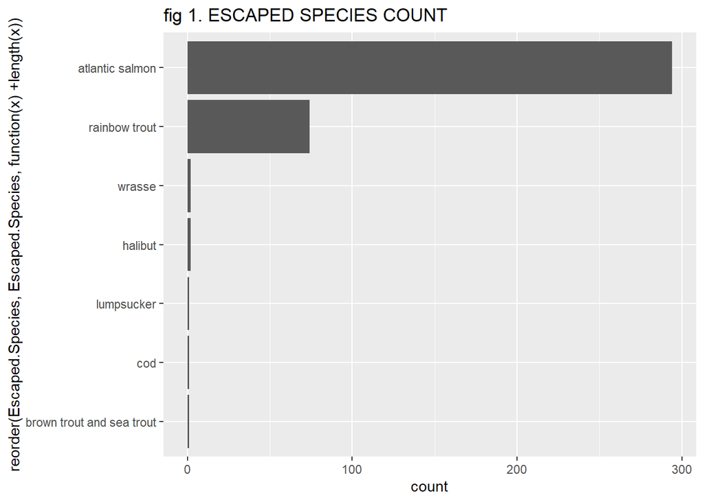

```r
## using ggplot
ggplot(escapesPlus,aes(y=reorder(Escaped.Species,Escaped.Species,function(x)+length(x)))) + geom_bar()+labs(title= "fig 1. ESCAPED SPECIES COUNT")
```

```r
# reordered bar plot: code from: https://stackoverflow.com/questions/5208679/order-bars-in-ggplot2-bar-graph
```

```r
# SALMON PRODUCER COUNT
total_operation <- length(escapesPlus$Operator)
sal<- 0 # accumulator variable to count atlantic salmon producers
RB_t<- 0 # accumulator variable to count rainbow trout producers
for(species in escapesPlus$Species){if(grepl("atlantic salmon",species)){sal=sal+1}
}
for(species in escapesPlus$Species){if(grepl("rainbow trout",species)){RB_t=RB_t+1}
}
print(paste("Total number of Operation captured in dataset is ",total_operation ))
```

```
## [1] "Total number of Operation captured in dataset is  375"
```

```r
print(paste("Total number of Atlantic salmon producer are :",sal ))
```

```
## [1] "Total number of Atlantic salmon producer are : 303"
```

```r
print(paste("also total number of rainbow trout producer:",RB_t ))
```

```
## [1] "also total number of rainbow trout producer: 72"
```

```r
non_salmon<- total_operation-sal
```

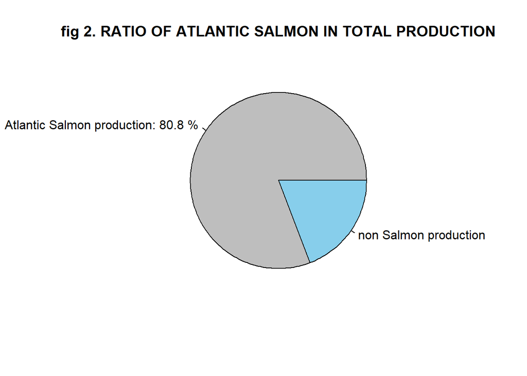

```r
# plotting Ratio of salmon production from total production
pie(c(sal,non_salmon),labels = c(paste("Atlantic Salmon production:",sal/total_operation*100,"%"),"non Salmon production" ),col=c("grey","skyblue"),main="fig 2. RATIO OF ATLANTIC SALMON IN TOTAL PRODUCTION")
```

The bar chart in fig 1. shows that most incidence happen to be the Atlantic Salmon, followed by the Rainbow Trout species before the other species. Further exploration and generation of the pie chart fig 2. above shows that the Atlantic Salmon is very popular with the Scottish fish farmer/producers and perhaps more economically viable hence the activity. Therefore focus maybe place on this specie and on the conditions that are leading to their escapes.

For a more general look at the data I would plot a correlation table also for any relationship and patterns between the numeric variables

CORRELATION PLOT to conduct a visualization of the general *escapePlus* dataset.

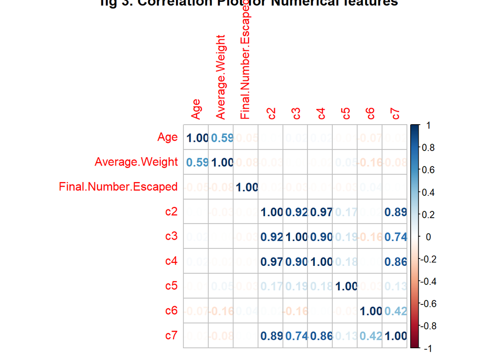

```r
numericals<-c() # to collect the features that class numeric so i can plot the correlations of this numerical values
for(feat in colnames(escapesPlus)){
  if (class(escapesPlus[feat][1,])=="numeric"){numericals<-c(numericals,feat)} # 1st fetching the numeric variables.
}
corrplot(cor(escapesPlus[,numericals],use="complete.obs"),method = "number",main="fig 3. Correlation Plot for Numerical features") # use set to complete.obs to accommodate the NA's in the set
```

the correlation plot above explains that there maybe some correlation between the water analysis features too.

### 4. Explorations with Random Forest Classifier Algorithm and Discussion.

#### 4.1 Preparing the data.

In order to learn, the data must have a class based target feature as the random forest is a supervised classifier. therefore I would transform my *Final.Number.Escaped* to a binary state of *0 meaning “no escape”* and *1 meaning escaped*. using threshold to value of >0, this will be saved in a new column “Bin_Escape”

```r
binarizer<- function(num){if(num>0){return (1)}else {return (0)}}
escapesPlus$Bin_Escape<- sapply(escapesPlus$Final.Number.Escaped,binarizer)
escapesPlus$Bin_Escape<- as.factor(escapesPlus$Bin_Escape)
#write.csv(escapesPlus,"escapesPlus.csv",row.names = FALSE) # update csv file
```

#### 4.2 The Model

I would be focusing on the numeric variables for this modeling stage to simplify the complexity of the model.

```r
# defining the train test controls as Out_of_Bag for bootstrap
trcont_oob <- trainControl(method = "oob") # oob for Out of Bag
```

I selected out of bag, though the performance wasn’t significantly better than with cross validation training control.

```r
set.seed(1234)  # set set to allow experiment be reproducible everytime
rf_model <- train(Bin_Escape~.,data=escapesPlus[c(numericals[-3],"Bin_Escape")],method="rf",metric="Accuracy",trControl = trcont_oob,maxnodes=11,ntree=300) # number of trees are limited to 300 and nodes to maximum of 5, lastly remove "Final.Number.Escaped" which is also another form of our target
print(rf_model)
```

```
## Random Forest
##
## 375 samples
##   8 predictor
##   2 classes: '0', '1'
##
## No pre-processing
## Resampling results across tuning parameters:
##
##   mtry  Accuracy   Kappa
##   2     0.6960000  0.1191379
##   5     0.7013333  0.1566604
##   8     0.7040000  0.1829424
##
## Accuracy was used to select the optimal model using the largest value.
## The final value used for the model was mtry = 8.
```

```r
#the forest optimize at maxnode = 11,
#number of trees remained fixed to 300 to reduce run time
#forest was trained only on numeric features of the dataset. I would investigate further to see how #non-numeric features can be used in forest at a later time.
```

#### 4.2.1 Main Results Discussion

Displaying the Variable Importance:

```r
varImp(rf_model)
```

```
## rf variable importance
##
##                Overall
## Age            100.000
## Average.Weight  44.153
## c6              23.078
## c7              11.780
## c5               8.686
## c3               7.308
## c4               4.699
## c2               0.000
```

As printed above in the variable importance ranking of the Model; *Age, Average weight* and the water analysis component measured as *c6* are the three most important variables. This mean that our forest model has “Age” being the most important variable; at the root the model before branching off and considering “Average.weight” and then to “c6” before the other numerical features.

#### 4.2.2 An extra exploratory look at Altantic Salmon instances only

```r
# CREATING NEW DATAFRAME WITH ONLY ATLANTIC SALMONS
Escaped_Salmons <- escapesPlus%>%filter(Escaped.Species=="atlantic salmon")
#summary(Escaped_Salmons)
dim(Escaped_Salmons)
```

```
## [1] 294  25
```

LEARNING applying same random forest and evaluating output model

```r
set.seed(1234)  # set set to allow experiment be reproducible everytime
rf_S_model <- train(Bin_Escape~.,data=Escaped_Salmons[c(numericals[-3],"Bin_Escape")],method="rf",metric="Accuracy",trControl = trcont_oob,maxnodes=14,ntree=300)
print(rf_S_model)
```

```
## Random Forest
##
## 294 samples
##   8 predictor
##   2 classes: '0', '1'
##
## No pre-processing
## Resampling results across tuning parameters:
##
##   mtry  Accuracy   Kappa
##   2     0.6462585  0.04889884
##   5     0.6326531  0.04637194
##   8     0.6496599  0.09719158
##
## Accuracy was used to select the optimal model using the largest value.
## The final value used for the model was mtry = 8.
```

```r
varImp(rf_S_model)
```

```
## rf variable importance
##
##                Overall
## Age            100.000
## Average.Weight  29.694
## c6              25.507
## c5              15.322
## c3              13.962
## c7               9.196
## c2               2.329
## c4               0.000
```

```
      *TABLE 1.*
```

*variable Importance Ranking*

[output not shown]

### Conclusion

This work involved the use of R to clean two data sets,to merge the datasets and then the selection of *Final.Number.Escaped* as target feature and performing of exploratory analysis in which I was able to show:

1. The relationship/correlation between variables.
2. The dominance of a certain class (Atlantic Salmon) in the dataset.
3. after performing classification using random forest, I was able to show the variable importance ranking for numerical features in the dataset.
4. and classifying only the class with the Atlantic Salmon I was able to find a variation in the variable importance ranking for this class and showed the difference from that of the general dataset.

Further exploration by including non numeric features to the my Random Forest models e.g “dates” or “site.name” may reveal more information.

## APPENDIX

Display of summary of data sets

ORIGINAL ESCAPES

```r
summary(escapes_ori)
```

```
##    Escape.ID                       Operator.at.Time.of.Escape Escape.Water.Type
##  Min.   :2000001   marine harvest (scotland) ltd: 59          b:  1
##  1st Qu.:2000153   the scottish salmon company  : 36          f: 85
##  Median :2000295   dawnfresh farming ltd        : 27          s:271
##  Mean   :2000289   scottish sea farms ltd       : 22
##  3rd Qu.:2000417   kames fish farming ltd       : 18
##  Max.   :2000527   grieg seafood shetland ltd   : 17
##                    (Other)                      :178
##  Escape.Start.Date Escape.Start.Time  Escape.End.Time Escape.Grid.Reference
##  11-Jan-05:  8     12:00  : 24       12-Jan-05:  3    nn762442:  7
##  13-Sep-06:  3     10:00  : 14       18-May-09:  3    nb137355:  6
##  18-May-09:  3     unknown: 14       17-Jan-12:  2    nf759032:  5
##  29-Jan-00:  3     11:00  : 12       17-Jan-20:  2    nn620240:  5
##  01-Apr-00:  2     09:00  : 10       23-Jan-14:  2    nr816412:  5
##  01-Apr-01:  2     (Other):113       (Other)  :200    (Other) :225
##  (Other)  :336     NA's   :170       NA's     :145    NA's    :104
##                   Escaped.Species                             Stage
##  atlantic salmon          :277    broodfish                      :  3
##  brown trout and sea trout:  1    fish weighing more than 5 grams: 84
##  cod                      :  1    grower fish (salmon only)      :247
##  halibut                  :  2    salmon fresh water stages      : 23
##  lumpsucker               :  1
##  rainbow trout            : 74
##  wrasse                   :  1
##         Age      Average.Weight Initial.Date.of.Escape Initial.Number.Escaped
##  12 months: 28   unknown: 15    14-Jan-05:  4          0        : 67
##  unknown  : 22   1 kg   : 13    13-Jan-05:  3          unknown  : 64
##  9 months : 16   3 kg   : 13    17-Jan-05:  3          1        : 12
##  15 months: 14   2.5 kg :  9    25-May-09:  3          not known:  8
##  18 months: 14   4 kg   :  9    02-Sep-19:  2          none     :  7
##  (Other)  :247   (Other):294    (Other)  :290          (Other)  :198
##  NA's     : 16   NA's   :  4    NA's     : 52          NA's     :  1
##                     Initial.Escape.Reason Final.Date.of.Escape
##  hole in net - hol             :68        04-Sep-19:  4
##  predator - prd                :65        03-Sep-18:  3
##  human error - hum             :49        08-Feb-05:  3
##  no actual escape of fish - nes:48        09-Feb-05:  3
##  weather - wth                 :47        25-Mar-20:  3
##  equipment damage - eqd        :21        (Other)  :283
##  (Other)                       :59        NA's     : 58
```

[output cut: 73 more lines]

```
##  strathclyde  :99   mowi scotland ltd             :78
##  highland     :87   the scottish salmon company   :76
##  western isles:71   dawnfresh farming ltd         :40
##  shetland     :48   scottish sea farms ltd        :38
##  tayside      :23   cooke aquaculture scotland ltd:36
##  orkney       :19   grieg seafood shetland ltd    :25
##  (Other)      :10   (Other)                       :64
##                                 Species
##  atlantic salmon                    : 63
##  rainbow trout                      : 61
##  atlantic salmon, wrasse, lumpsucker: 40
##  atlantic salmon, lumpsucker, wrasse: 34
##  lumpsucker, atlantic salmon, wrasse: 30
##  wrasse, atlantic salmon, lumpsucker: 27
##  (Other)                            :102
```

ORIGINAL ANALYSIS

```r
summary(analysis_ori)
```

```
##       year          month                  Site.Name         c2
##  Min.   :1998   Min.   : 1.000   Balta Isle     :  8   Min.   :0.2800
##  1st Qu.:2005   1st Qu.: 3.000   Eilean Grianain:  8   1st Qu.:0.8775
##  Median :2008   Median : 6.000   Loch Earn      :  8   Median :1.4070
##  Mean   :2009   Mean   : 6.405   Loch Tay       :  8   Mean   :1.4082
##  3rd Qu.:2015   3rd Qu.:10.000   Loch Lochy     :  6   3rd Qu.:1.9245
##  Max.   :2020   Max.   :12.000   Taranaish      :  6   Max.   :2.6990
##                                  (Other)        :307
##        c3               c4               c5                c6
##  Min.   :0.0000   Min.   :0.1943   Min.   :0.01528   Min.   :0.03842
##  1st Qu.:0.1440   1st Qu.:0.6376   1st Qu.:0.01738   1st Qu.:0.07764
##  Median :0.3220   Median :1.0420   Median :0.01804   Median :0.09299
##  Mean   :0.3384   Mean   :1.0600   Mean   :0.01805   Mean   :0.09336
##  3rd Qu.:0.5175   3rd Qu.:1.4603   3rd Qu.:0.01877   3rd Qu.:0.10709
##  Max.   :0.9600   Max.   :2.2184   Max.   :0.02062   Max.   :0.16728
##
##        c7
##  Min.   :0.02807
##  1st Qu.:0.08614
##  Median :0.15394
##  Mean   :0.15759
##  3rd Qu.:0.21460
##  Max.   :0.38359
##
```

CLEANED ESCAPESPLUS

```r
summary(escapesPlus)
```

```
##
## Imputed Values:
##
## [1] 4000  617  617  617   27 1000 1000 6000  100
```

```
##      Date                     Site.Name     Escape.ID   Escape.Water.Type
##  Length:375         eilean grianain: 12   2000483:  3   b:  1
##  Class :character   balta isle     : 10   2000484:  3   f: 85
##  Mode  :character   corlarach      : 10   2000485:  3   s:289
##                     loch tay       : 10   2000040:  2
##                     loch earn      :  8   2000041:  2
##                     taranaish      :  8   2000073:  2
##                     (Other)        :317   (Other):360
##  Escape.Start.Date                  Escaped.Species
##  11-Jan-05:  9     atlantic salmon          :294
##  25-Mar-17:  4     brown trout and sea trout:  1
##  04-Jan-19:  3     cod                      :  1
##  06-Jan-19:  3     halibut                  :  2
##  09-Jan-19:  3     lumpsucker               :  1
##  13-Sep-06:  3     rainbow trout            : 74
##  (Other)  :350     wrasse                   :  2
##                              Stage          Age        Average.Weight
##  broodfish                      :  3   Min.   : 0.75   Min.   : 0.01079
##  fish weighing more than 5 grams: 84   1st Qu.:11.00   1st Qu.: 0.60000
##  grower fish (salmon only)      :265   Median :14.00   Median : 2.00000
##  salmon fresh water stages      : 23   Mean   :14.33   Mean   : 2.09490
##                                        3rd Qu.:18.00   3rd Qu.: 3.15000
##                                        Max.   :48.00   Max.   :10.00000
##
##  Final.Number.Escaped Final.Escape.Reason Marine.Scotland.Site.ID
##  Min.   :     0       Length:375          fs1176 : 12
##  1st Qu.:     0       Class :character    fs0432 : 10
##  Median :   400       Mode  :character    fs0717 : 10
##  Mean   : 10438                           fs1287 : 10
##  3rd Qu.:  7398                           fs0180 :  8
##  Max.   :336470                           fs0752 :  8
##                                           (Other):317
##  Producing.in.Last.3.Years                           Operator
##  no : 52                   the scottish salmon company   :83
##  yes:323                   mowi scotland ltd             :81
##                            dawnfresh farming ltd         :39
##                            scottish sea farms ltd        :39
##                            cooke aquaculture scotland ltd:38
##                            grieg seafood shetland ltd    :30
##                            (Other)                       :65
```

[output cut: 17 more lines]

```
##  Min.   :0.1943   Min.   :0.01528   Min.   :0.03842   Min.   :0.02807
##  1st Qu.:0.6129   1st Qu.:0.01739   1st Qu.:0.07716   1st Qu.:0.08490
##  Median :1.0389   Median :0.01805   Median :0.09288   Median :0.15054
##  Mean   :1.0649   Mean   :0.01806   Mean   :0.09329   Mean   :0.15738
##  3rd Qu.:1.4744   3rd Qu.:0.01876   3rd Qu.:0.10735   3rd Qu.:0.21621
##  Max.   :2.2184   Max.   :0.02062   Max.   :0.16728   Max.   :0.38359
##
##  Bin_Escape
##  0:124
##  1:251
##
##
##
##
##
```